# Análisis multinivel, jerárquica, anidados, o de regresión de efectos mixtos

2024-06-12

# 1 AMN para datos anidados

El objetivo general de la regresión logística multinivel es estimar las probabilidades de que ocurra un evento (el resultado de sí/no) teniendo en cuenta la dependencia de los datos (el hecho de que los alumnos estén agrupados en las aulas y que pertenezcan a diferentes colegios, distritos, departamentos, países e incluso periodos de tiempo [1996 vs 2020]). En la práctica, le permitirá estimar dichas probabilidades en función de variables de nivel inferior (por ejemplo, la edad del alumno), variables de nivel superior (por ejemplo, tamaño del aula) y la forma en que se interrelacionan (interacciones entre niveles).

La regresión logística multinivel se puede utilizar para una variedad de situaciones comunes en ciencias de la salud, como cuando la variable de resultado describe la presencia/ausencia de un evento o una enfermedad. Por ejemplo, se ha utilizado la regresión logística multinivel para probar la influencia de la experiencia de los individuos de un evento vital negativo y la calidad de su vecindario en las probabilidades de depresión ( Cutrona et al., 2005 ), o la influencia del género de los solicitantes de subvenciones y el género de sus revisores en las probabilidades de financiación ( Mutz, Bornmann y Daniel, 2015 ). El modelado multinivel también se puede aplicar a diseños de medidas repetidas. Por ejemplo, si los participantes reciben entrenamiento durante varias semanas, el uso de este enfoque permitirá a los usuarios avanzados tener en cuenta tanto los estímulos como las variaciones entre los participantes.

**¿Qué es la regresión logística multinivel?**

Ahora suponga que su estudio involucra a N = 2000 alumnos de K = 100 aulas. Es decir, tiene N participantes (unidades de nivel 1) anidados en K grupos (unidades de nivel 2). Las aulas pertenecen a un nivel (más que a una variable individuales), ya que:

1. las aulas se tomaron muestras aleatoriamente de una población de unidades (las aulas de todo el mundo son potencialmente infinitas y usted ha muestreado algunas de ellas), y
2. las aulas no tienen significado intrínseco per se (las aulas son unidades intercambiables sin contenido teórico).

Por el contrario, el estatus socioeconómico pertenecería, por ejemplo, a un individuo (más que a un nivel), ya que sus categorías no son aleatorias y son teóricamente significativas (por ejemplo, las clases baja, media y alta no son unidades aleatorias “ateóricas”).

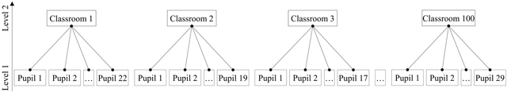

Ejemplo de una estructura de datos jerárquica, en la que N participantes (alumnos, unidades de nivel inferior) están anidados en K grupos (aulas, unidades de nivel superior). Notas : El modelado multinivel es lo suficientemente flexible como para manejar este tipo de datos desequilibrados, es decir, con números desiguales de participantes dentro de los grupos.

Con una estructura de datos de este tipo, no se puede ejecutar un análisis de regresión logística estándar. La razón es que esto viola uno de los supuestos más importantes de los modelos lineales generalizados, el supuesto de independencia (o falta de correlación) de los residuos ( Bressoux, 2010 ).

**¿Por qué no serían observaciones interdependientes?**

Los participantes anidados en el mismo grupo tienen más probabilidades de funcionar de la misma manera que los participantes anidados en grupos diferentes. En nuestro ejemplo, puede haber algunas aulas en las que se adora a Justin Bieber (y los alumnos tienen más posibilidades de poseer el último álbum de Justin) y otras aulas en las que se aborrece a Justin Bieber (y los alumnos tienen menos posibilidades de poseer el último álbum de Justin).

El modelado multinivel (logístico) apunta en particular a desenredar los efectos dentro del grupo (la medida en que algunas características de los participantes están asociadas con las probabilidades de poseer el último álbum de Justin) de los efectos entre grupos (la medida en que algunas características del aula están asociadas con las probabilidades de poseer el último álbum de Justin).

**¿Qué pasa con el tamaño de la muestra?**

Un tamaño de muestra suficiente es uno de los primeros indicios de la calidad de la investigación ( Świątkowski y Dompnier, 2017 ). En el modelado multinivel, el número de conglomerados es más importante que el número de observaciones por conglomerado ( Swaminathan, Rogers y Sen, 2011 ). En el modelado lineal multinivel, los estudios de simulación muestran que se necesitan 50 o más unidades de nivel 2 para estimar con precisión los errores estándar ( Maas & Hox, 2005 ; ver también Paccagnella, 2011 ). Más concretamente, en el modelado logístico multinivel, Schoeneberger ( 2016 ) demostró que se necesita un mínimo de 50 unidades de nivel 1 y 40 unidades de nivel 2 para estimar con precisión pequeños efectos fijos (establecidos en OR = 1,70) cuando la varianza del intercepto es pequeña. (establecido en var( u 0j ) ≈ 0,1), mientras que se necesitan 100 unidades de nivel 1 y 80 unidades de nivel 2 cuando se estiman los efectos de interacción entre niveles y/o cuando la varianza del intercepto es grande (establecido en var( u 0j ) ≈ 0,5).

Un tamaño de muestra insuficiente obviamente reduce el poder estadístico (la probabilidad de “detectar” un efecto verdadero); además, un tamaño de muestra insuficiente en el nivel 2 aumenta las tasas de error de tipo I correspondientes al efecto fijo del nivel 2 (el riesgo de “detectar” un efecto falso). Para detectar con mayor precisión el sesgo en los coeficientes de regresión y los errores estándar debido al tamaño de la muestra en ambos niveles, los usuarios avanzados deberían considerar realizar un estudio de Monte Carlo (por ejemplo, Muthèn y Muthèn, 2002 ).

## 1.1 Implicaciones del modelo multinivel

**Una primera implicación: las probabilidades logarítmicas pueden variar entre grupos**

La primera diferencia entre la regresión logística simple y multinivel es que se permite que las probabilidades logarítmicas de que la variable de resultado sea igual a uno en lugar de cero varíen de un grupo a otro. Para ilustrar esto, regrese a su estudio e imagine construir un modelo logístico multinivel vacío. Este modelo todavía apunta a estimar las probabilidades logarítmicas de poseer el álbum de Justin, sin incluir predictores. Esta ecuación de regresión logística multinivel vacía se muestra a continuación (Ec. 4):

${\rm{Logit}}\left({odds} \right) = {B_{00}} + {u_{{\rm{0j}}}}$ ………(4)

…en el que Logit( probabilidades ) son las probabilidades logarítmicas de que la variable de resultado sea igual a uno en lugar de cero (es decir, la probabilidad de que un alumno i de un aula j posea el último álbum de Justin).

…y B 00 es la intersección fija, mientras que $\text{u 0j}$ es la desviación de la intersección específica del conglomerado respecto de la intersección fija (es decir, el residual de nivel 2).

Primero, recuerde que no estamos tratando de predecir las probabilidades logarítmicas de poseer el álbum de Justin para un simple participante ; Estamos tratando de predecir tales probabilidades logarítmicas para un participante i en un aula j .

En segundo lugar, ahora estamos estimando dos tipos de parámetros relacionados con la intersección: la intersección fija y la varianza de la intersección aleatoria . Vayamos paso a paso.

La intersección fija B 00 es un término constante general. Dado que aquí no hay predictores, la intersección fija B 00 corresponde a las probabilidades logarítmicas generales de poseer el álbum de Justin (en lugar de no poseerlo) para un alumno típico que pertenece a un aula típica. Tenga en cuenta que todavía estamos estimando las probabilidades logarítmicas (o el logit de las probabilidades). Si desea calcular la probabilidad promedio de poseer el álbum, debe convertir la intersección fija usando la transformación logit. En su estudio, B 00 = 0,10, por lo tanto $P(Y ij = 1) = exp ( B 00 )/(1 + exp ( B 00 ) = 1,10/(1 + 1,10) ≈ 0,52$, es decir, los alumnos tienen en promedio “52% de posibilidades de poseer el álbum de Justin en todas las aulas” .

Pero como se señaló anteriormente, las probabilidades logarítmicas pueden variar de un grupo a otro. En otras palabras, la intersección no es la misma en todos los grupos. El residual de nivel 2 u 0j proporcionará información sobre el alcance de la variación de la intersección. Dado que aquí no hay predictores, el residuo de nivel 2 u 0j corresponde a la desviación de las probabilidades logarítmicas específicas de poseer el álbum de Justin en un aula determinada de las probabilidades logarítmicas generales de poseer el álbum de Justin en todas las aulas (la media de estos se supone que las desviaciones son cero). El componente de la varianza de dicha desviación es la varianza del intercepto aleatorio var( u 0j ). Este es el elemento clave aquí: cuanto mayor sea la varianza de la intercepción aleatoria, mayor será la variación de las probabilidades logarítmicas de poseer el álbum de Justin de un grupo a otro; esto indica que los alumnos tienen más posibilidades de poseer el álbum de Justin en algunas aulas que en otras

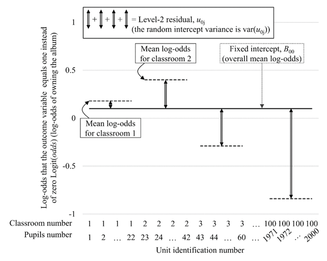

**Una segunda implicación: el efecto de una variable de nivel inferior puede variar entre grupos**

El segundo cambio con el modelado logístico multinivel es que se permite que el efecto de una variable de nivel inferior varíe de un grupo a otro. Antes de entrar en detalles, debemos distinguir entre las variables de nivel 1, denominadas x ij (en minúsculas), y las variables de nivel 2, denominadas X j (en mayúsculas y negrita). Por un lado, las variables de nivel 1 son características de observación de nivel inferior (por ejemplo, la edad del alumno). El valor de una variable de nivel 1 puede cambiar dentro de un grupo determinado (puede haber alumnos de diferentes edades dentro de la misma clase). Por otro lado, las variables de nivel 2 son características de conglomerados de nivel superior (por ejemplo, el tamaño de la clase). El valor de una variable de nivel 2 no puede cambiar dentro de los grupos (el tamaño de la clase es obviamente el mismo para todos los alumnos dentro de un aula).

Podemos entender que el efecto de una variable de nivel 1, pero no el de una variable de nivel 2 (!), puede variar de un grupo a otro. Por ejemplo, el efecto de la edad del alumno sobre alguna variable de resultado puede ser positivo en algunas aulas y negativo en otras. Esto también significa que el efecto promedio podría no ser estadísticamente significativo, porque es positivo en la mitad de las aulas y negativo en la otra mitad. Por lo tanto, considerar sólo el efecto fijo en presencia de diferencias entre aulas puede llevar a concluir erróneamente que el efecto es insignificante, cuando en realidad el efecto es positivo (o más fuerte) en algunos grupos y negativo (o más débil) en otros.

Para ilustrar esto, regrese a su estudio e imagine construir un modelo de regresión logística multinivel simple. Este modelo tiene como objetivo estimar las probabilidades logarítmicas de poseer el álbum de Justin utilizando el **GPA (promedio de calificaciones)** como único predictor. Esta sencilla ecuación de regresión logística multinivel se muestra a continuación (Ec. 5):

${\rm{Logit}}\left({odds} \right) = {B_{00}} + ({B_{10}} + {u_{{\rm{1j}}}})\ {^*}\ {{\rm{x}}_{{\rm{ij}}}} + {u_{{\rm{0j}}}}$ ……………(5)

…en el que x ij es el valor observado de la variable predictiva para un alumno i en un aula j (su GPA);

…y B 10 es la pendiente fija, mientras que **u 1j** es la desviación de la pendiente específica del grupo respecto de la pendiente fija (es decir, el término residual asociado con la variable de nivel 1).

Además de (todavía) tener dos tipos de parámetros relacionados con la intersección (la intersección fija B 00 y la varianza de la intersección aleatoria var( u 0j ), ahora tenemos dos tipos de parámetros relacionados con el efecto de nivel 1: La pendiente fija y la varianza de la pendiente aleatoria.

Nuevamente, vayamos paso a paso.

La pendiente fija B 10 es el efecto general de la variable de nivel 1 x ij . La interpretación es similar al caso de un análisis de regresión logística de un solo nivel: un aumento de una unidad en el GPA da como resultado un cambio de B 10 en las probabilidades logarítmicas generales de poseer el álbum de Justin para un alumno típico que pertenece a un aula típica. Una vez más, para interpretar B 10 , elévelo al exponente para obtener la razón de probabilidades. En su estudio, B 10 = 0,70, OR = exp ( B 10 ) = exp (0,70) ≈ 2, es decir, cuando el GPA aumenta en una unidad, los alumnos tienen el doble de probabilidades de poseer el álbum de Justin en lugar de no poseerlo en todos los casos - aulas (es decir, un aumento del 100%).

Al igual que la intercepción, este efecto puede variar de un grupo a otro. El término residual asociado con el predictor de nivel 1 u 1j proporcionará información sobre el alcance de la variación del efecto. Específicamente, este residual u 1j corresponde a la desviación de los efectos específicos de la variable de nivel 1 x ij en un aula determinada del efecto general de la variable de nivel 1 x ij en todas las aulas (se supone que la media de estas desviaciones es ser cero). El componente de varianza de dicha desviación es la varianza de la pendiente aleatoria var( u 1j ). Este es el elemento clave aquí: cuanto mayor sea la varianza de la pendiente aleatoria, mayor será la variación del efecto del GPA de un grupo a otro.

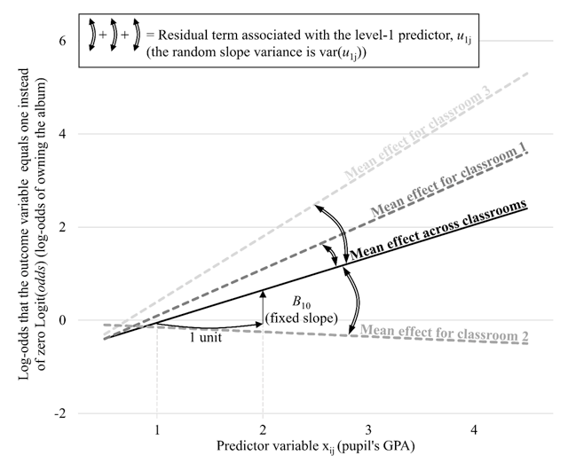

## 1.2 Procedimiento

Recuerda:

1. la regresión logística multinivel permite predecir las probabilidades logarítmicas de que una variable de resultado sea igual a uno en lugar de cero (recuerde mis palabras: algunos paquetes de software, por ejemplo SPSS, hacen lo contrario y estiman la probabilidad de que siendo el resultado cero en lugar de uno).
2. se permite que las probabilidades logarítmicas promedio varíen de un grupo a otro (formando la varianza del intercepto aleatorio), y (c) también se puede permitir que un efecto de nivel inferior varíe de un grupo a otro (formando la varianza de la pendiente aleatoria).

Los pasos del procedimiento son los siguientes:

1. Fase preliminar: Preparación de los datos (centrado de variables)
2. Paso #1: Construir un modelo vacío, para evaluar la variación de las probabilidades logarítmicas de un grupo a otro
3. Paso #2: Construir un modelo intermedio, para evaluar la variación de los efectos de nivel inferior de un grupo a otro
4. Paso #3: Construir un modelo final para probar la(s) hipótesis(s)

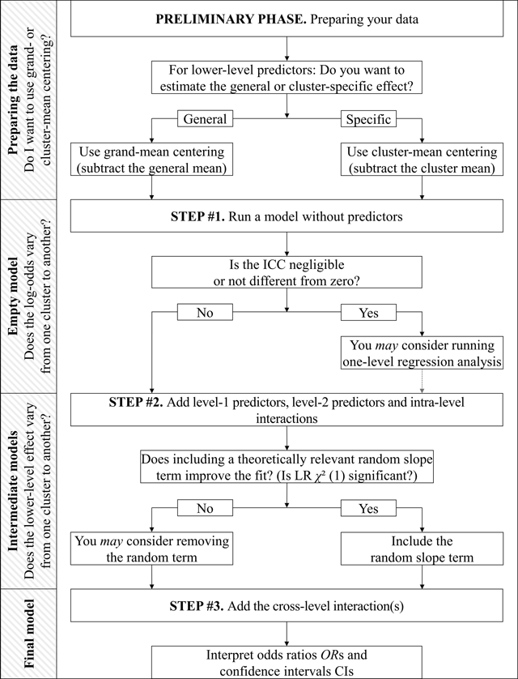

Estás tratando de predecir las probabilidades de que los alumnos posean el último álbum de Justin y planteas dos hipótesis. Primero, predices que el gusto musical de los alumnos está influenciado por el gusto musical de sus profesores:

- Hipótesis del efecto principal: Los alumnos tienen más probabilidades de poseer el álbum de Justin cuando su profesor es creyente que cuando no lo es.

Segundo, planteas que los estudiantes con un GPA alto tienden a identificarse más con sus profesores y, por lo tanto, deberían estar más influenciados por ellos, mientras que los de bajo rendimiento estarán menos influenciados:

- Hipótesis de interacción entre niveles: Los alumnos con un GPA alto tienen más probabilidades de poseer el álbum de Justin cuando su profesor es creyente que cuando no lo es; este efecto es menos pronunciado para los alumnos con un GPA bajo.

## 1.3 Proceso de análisis

Carla la base de datos proporcionada

```r
load("Dataset R.rdata")

attr(d$pupils, "labels") <-  "level-1 identifier"
attr(d$classes, "labels") <-  "level-2 identifier"
attr(d$gpa, "labels")    <-  "level-1 predictor variable"
attr(d$teacher_fan, "labels") <-"level-2 predictor variable"
attr(d$bieber, "labels") <-  "binary outcome variable"
```

|  | pupils | classes | gpa | teacher_fan | bieber |
| --- | --- | --- | --- | --- | --- |
| 1 | 1 | 1 | 2 | 0 | 1 |
| 2 | 2 | 1 | 3 | 0 | 0 |
| 3 | 3 | 1 | 3 | 0 | 0 |
| 4 | 4 | 1 | 3 | 0 | 1 |
| 5 | 5 | 1 | 2 | 0 | 1 |
| 6 | 6 | 1 | 3 | 0 | 0 |
| 7 | 7 | 1 | 3 | 0 | 0 |
| 8 | 8 | 1 | 3 | 0 | 1 |
| 9 | 9 | 1 | 3 | 0 | 1 |
| 10 | 10 | 1 | 3 | 0 | 1 |

[output cut: 1990 more lines]

## 1.4 Fase preliminar: Preparación de datos y centrado

Centrar las variables predictoras puede facilitar la interpretación de las estimaciones. Una variable de nivel 2 se centra en la media global, mientras que una de nivel 1 puede centrarse en la media global o en la media del grupo.

Centrar en la media global implica restar la media general de la variable (x̄) de cada observación. Por otro lado, centrar en la media del grupo implica restar la media específica del grupo.

Tenga en cuenta que el tipo de centrado (grupo versus gran media) puede afectar su modelo y sus resultados. La elección de uno u otro debe realizarse en función de su pregunta de investigación específica. Por ejemplo, se recomienda el centrado en media general si está interesado en el efecto de una variable predictiva de nivel 2 o el efecto absoluto (entre observaciones) de una variable predictiva de nivel 1, mientras que se recomienda el centrado en media de conglomerados cuando el enfoque está en el efecto relativo (dentro del grupo) de una variable de nivel 1. En nuestro ejemplo, usted decide agrupar la media central del GPA de los alumnos (es decir, restar la media específica del aula, para estimar el efecto dentro del aula) y centrar el cariño del profesor por Bieber utilizando –0,5 para “no soy un creyente” y +0,5. para “belieber” porque su objetivo es probar la idea de que los estudiantes de mayor rendimiento de un aula determinada tienen más probabilidades de ser influenciados por su maestro.

```r
#A continuación se muestran los comandos para centrar la media general de "gpa" (es decir, restando la media general de la variable predictora).
#La nueva variable es "gpa_gmc".
grand_mean_gpa <- mean(d$gpa, na.rm=T)
d$gpa_gmc <- d$gpa - grand_mean_gpa


#A continuación se muestran los comandos para agrupar-centrar la media de "gpa" (es decir, restando la media específica de la clase de la variable predictora).
#La nueva variable es "gpa_cmc".
cluster_mean_gpa <- data.frame(tapply(d$gpa, d$classes, mean))
cluster_mean_gpa$classes <- rownames(cluster_mean_gpa)
names(cluster_mean_gpa)<- c("cluster_mean_gpa","classes")
d <- merge(d, cluster_mean_gpa, by="classes")
d$gpa_cmc <- d$gpa - d$cluster_mean_gpa


#Below is the command to center "teacher_fan"
d$teacher_fan_c <- NA
d$teacher_fan_c[d$teacher_fan==0] <- -0.5
d$teacher_fan_c[d$teacher_fan==1] <- 0.5
```

## 1.5 Paso 1: Construcción de un modelo vacío

Ejecuta un modelo vacío para medir la variabilidad entre aulas en las probabilidades de poseer el álbum. Calcula el coeficiente de correlación intraclase (ICC) para evaluar la homogeneidad dentro de las aulas.

${\rm{ICC}} = \frac{{{\rm{var}}({u_{{\rm{0j}}}})}}{{{\rm{var}}({u_{{\rm{0j}}}}) + \left({{\pi ^2} \ / \ 3} \right)}}$

…en el que var( u 0j ) es la varianza del intercepto aleatorio, es decir, el componente de varianza de nivel 2: cuanto mayor var( u 0j ), mayor es la variación de las probabilidades logarítmicas promedio entre conglomerados;

…y (π 2 /3) ≈ 3.29 se refiere a la distribución logística estándar, es decir, el componente de varianza de nivel 1 asumido: Tomamos este valor asumido, ya que el modelo de regresión logística no incluye el residual de nivel 1

El ICC puede oscilar entre 0 y 1. ICC = 0 indica perfecta independencia de los residuos: las observaciones no dependen de la pertenencia al grupo. La posibilidad de poseer el álbum de Justin no difiere de un aula a otra (no hay variación entre aulas). Cuando el ICC no es diferente de cero o insignificante, se podría considerar ejecutar un análisis de regresión tradicional de un nivel. 5 Sin embargo, ICC = 1 indica una interdependencia perfecta de los residuos: las observaciones solo varían entre conglomerados. En un aula determinada, todo el mundo o nadie posee el álbum de Justin (no hay variación dentro del aula).

```r
#Import the library for multilevel logistic modeling
library(lme4)
library(performance)
library(equatiomatic)


#Below are the commands to run an empty model, that is, a model containing no predictors,
# and calculate the intraclass correlation coefficient (ICC; the degree of homogeneity of the outcome within clusters).


M0 <- glmer(bieber ~ ( 1 | classes), data=d, family = "binomial")

#Formula
equatiomatic::extract_eq(M0)
```

$$\begin{aligned}
\operatorname{bieber}_{i} &\sim \operatorname{Binomial}(n = 1,
\operatorname{prob}_{\operatorname{bieber} = 1} = \widehat{P}) \\
\log\left[\frac{\hat{P}}{1 - \hat{P}} \right] &=\alpha_{j[i]} \\
\alpha_{j} &\sim N \left(\mu_{\alpha_{j}},
\sigma^2_{\alpha_{j}} \right)
\text{, for classes j = 1,} \dots \text{,J}
\end{aligned}$$

```r
# Resumen
summary(M0)
## Generalized linear mixed model fit by maximum likelihood (Laplace Approximation) [glmerMod
## ]
##  Family: binomial  ( logit )
## Formula: bieber ~ (1 | classes)
##    Data: d
##
##      AIC      BIC   logLik deviance df.resid
##     2497     2508    -1246     2493     1998
##
## Scaled residuals:
##    Min     1Q Median     3Q    Max
## -2.659 -0.749  0.318  0.756  2.226
##
## Random effects:
##  Groups  Name        Variance Std.Dev.
##  classes (Intercept) 1.25     1.12
## Number of obs: 2000, groups:  classes, 100
##
## Fixed effects:
##             Estimate Std. Error z value Pr(>|z|)
## (Intercept)    0.103      0.123    0.83      0.4
```

```r
#ICC
icc(M0)
```

| ICC_adjusted | ICC_unadjusted | optional |
| --- | --- | --- |
| 0.276 | 0.276 | FALSE |

```r
icc <- M0@theta[1]^2/ (M0@theta[1]^2 + (3.14159^2/3))
icc
```

```
## [1] 0.276
```

```r
#########
#interpretación#
#########
#N = 2000 alumnos están anidados en K = 100 clases (n = 20 alumnos por clase);
#El intercepto fijo está en la parte "Efectos fijos" de la salida: (Intercepto) 0,1028;
#La varianza del intercepto aleatorio (es decir, el residuo de nivel 2) se encuentra en la parte "Efectos aleatorios" del resultado: clases (Intercepto) 1,254;
#El coeficiente de correlación intraclase es ICC = .28;
#Esto indica que el 28% de las posibilidades de poseer un álbum se explica por diferencias entre aulas (y, a la inversa, que el 72% se explica por diferencias dentro de las aulas).
```